# A Vignette for DeMixT

Zeya Wang, Fan Gao, Shaolong Cao and Peng Yang

2020-01-18

# 1. Introduction

Transcriptomic deconvolution in cancer and other heterogeneous tissues remains challenging. Available methods lack the ability to estimate both component-specific proportions and expression profiles for individual samples. We develop a three-component deconvolution model, DeMixT, for expression data from a mixture of cancerous tissues, infiltrating immune cells and tumor microenvironment. DeMixT is a software package that performs deconvolution on transcriptome data from a mixture of two or three components.

DeMixT is a frequentist-based method and fast in yielding accurate estimates of cell proportions and compart-ment-specific expression profiles for two-component three-component deconvolution problem. Our method promises to provide deeper insight into cancer biomarkers and assist in the development of novel prognostic markers and therapeutic strategies.

The function DeMixT is designed to finish the whole pipeline of deconvolution for two or three components. The newly added DeMixT_GS function is designed to estimates the proportions of mixed samples for each mixing component based on a new approach to select genes more effectively that utilizes profile likelihood. DeMixT_S1 function is designed to estimate the proportions of all mixed samples for each mixing component based on the gene differential expressions to select genes. DeMixT_S2 function is designed to estimate the component-specific deconvolved expressions of individual mixed samples for a given set of genes.

# 2 Feature Description

The DeMixT R-package builds the transcriptomic deconvolution with a couple of novel features into R-based standard analysis pipeline through Bioconductor. DeMixT showed high accuracy and efficiency from our designed experiment. Hence, DeMixT can be considered as an important step towards linking tumor transcriptomic data with clinical outcomes.

Different from most previous computational deconvolution methods, DeMixT has integrated new features for the deconvolution with more than 2 components.

**Joint estimation**: jointly estimate component proportions and expression profiles for individual samples by requiring reference samples instead of reference genes; For the three-component deconvolution considering immune infiltration, it provides a comprehensive view of tumor-stroma-immune transcriptional dynamics, as compared to methods that address only immune subtypes within the immune component, in each tumor sample.

**Efficient estimation**: DeMixT adopts an approach of iterated conditional modes (ICM) to guarantee a rapid convergence to a local maximum. We also design a novel gene-set-based component merging approach to reduce the bias of proportion estimation for three-component deconvolutionthe.

**Parallel computing**: OpenMP enables parallel computing on single computer by taking advantage of the multiple cores shipped on modern CPUs. The ICM framework further enables parallel computing, which helps compensate for the expensive computing time used in the repeated numerical double integrations.

# 3. Installation

## 3.1 Source file

DeMixT source files are compatible with Windows, Linux and macOS.

DeMixT_1.2.2 is the latest version, which is for a computer that has OpenMP. It can be downloaded from Bioconductor website. https://bioconductor.org/packages/release/bioc/html/DeMixT.html

To install DeMixT_1.2.2 from GitHub, start R and enter:

```r
# devtools::install_github("wwylab/DeMixT")
```

For more information, please visit: http://bioinformatics.mdanderson.org/main/DeMixT

## 3.2 Functions

The following table shows the functions included in DeMixT.

| Table Header | Second Header |
| --- | --- |
| DeMixT | Deconvolution of tumor samples with two or three components |
| DeMixT_GS | Estimates the proportions of mixed samples for each mixing component based on a new approach to select genes that utilizes profile likelihood |
| DeMixT_S1 | Estimates the proportions of mixed samples for each mixing component |
| DeMixT_S2 | Deconvolves expressions of each sample for unknown component |
| Optimum_KernelC | Call the C function used for parameter estimation in DeMixT |

# 4. Methods

## 4.1 Model

Let $Y_{ig}$ be the observed expression levels of the raw measured data from clinically derived malignant tumor samples for gene $g, g = 1, \cdots, G$ and sample $i, i = 1, \cdots, My$. $G$ denotes the total number of probes/genes and $My$ denotes the number of samples. The observed expression levels for solid tumors can be modeled as a linear combination of raw expression levels from three components:
$${Y_{ig}} = \pi _{1,i}N_{1,ig} + \pi _{2,i}N_{2,ig} +
(1 - \pi_{1,i} - \pi _{2,i}){T_{ig}} \label{eq:1}$$

Here $N_{1,ig}$, $N_{2,ig}$ and ${T_{ig}}$ are the unobserved raw expression levels from each of the three components. We call the two components for which we require reference samples the $N_1$-component and the $N_2$-component. We call the unknown component the T-component. We let $\pi_{1,i}$ denote the proportion of the $N_1$-component, $\pi_{2,i}$ denote the proportion of the $N_2$-component, and $1 - \pi_{1,i}-\pi_{2,i}$ denote the proportion of the T-component. We assume that the mixing proportions of one specific sample remain the same across all genes.

Our model allows for one component to be unknown, and therefore does not require reference profiles from all components. A set of samples for $N_{1,ig}$ and $N_{2,ig}$, respectively, needs to be provided as input data. This three-component deconvolution model is applicable to the linear combination of any three components in any type of material. It can also be simplified to a two-component model, assuming there is just one $N$-component. For application in this paper, we consider tumor ($T$), stromal ($N_1$) and immune components ($N_2$) in an admixed sample ($Y$).

Following the convention that $\log_2$-transformed microarray gene expression data follow a normal distribution, we assume that the raw measures $N_{1,ig} \sim LN({\mu _{{N_1}g}},\sigma _{{N_1}g}^2)$, $N_{2,ig} \sim LN({\mu _{{N_2}g}},\sigma _{{N_2}g}^2)$ and ${T_{ig}} \sim LN({\mu _{Tg}}, \sigma _{Tg}^2)$, where LN denotes a $\log_2$-normal distribution and $\sigma _{{N_1}g}^2$,$\sigma _{{N_2}g}^2$, $\sigma _{Tg}^2$ reflect the variations under $\log_2$-transformed data. Consequently, our model can be expressed as the convolution of the density function for three $\log_2$-normal distributions. Because there is no closed form of this convolution, we use numerical integration to evaluate the complete likelihood function (see the full likelihood in the Supplementary Materials).

## 4.2 The DeMixT algorithm for deconvolution

1. Obtain a set of parameters $\{\pi_{1,i}, \pi_{2,i}\}_{i=1}^{My}$, $\{\mu_T, \sigma_T\}_{g=1}^G$ to maximize the complete likelihood function, for which $\{\mu_{N_{1,g}}, \sigma_{N_{1,g}}, \mu_{N_{2,g}}, \sigma_{N_{2,g}}\}_{g=1}^G$ were already estimated from the available unmatched samples of the $N_1$ and $N_2$ component tissues. (See further details in our paper.)
2. Reconstitute the expression profiles by searching each set of $\{n_{1,ig}, n_{2,ig}\}$ that maximizes the joint density of $N_{1,ig}$, $N_{2,ig}$ and $T_{ig}$. The value of $t_{ig}$ is solved as ${y_{ig}} - {{\hat \pi }_{1,i}}{n_{1,ig}} - {{\hat \pi }_{2,i}}{n_{2,ig}}$.

These two steps can be separately implemented using the function DeMixT_S1 or DeMixT_GS for the first step and DeMixT_S2 for the second, which are combined in the function DeMixT(Note: DeMixT_GS is the default function for first step).

In version 1.2.2, DeMixT added simulated normal reference samples, i.e., spike-in, based on the observed normal reference samples. It has been shown to improve accuracy in proportion estimation for the scenario where a dataset consists of samples where true tumor proportions are skewed to the high end.

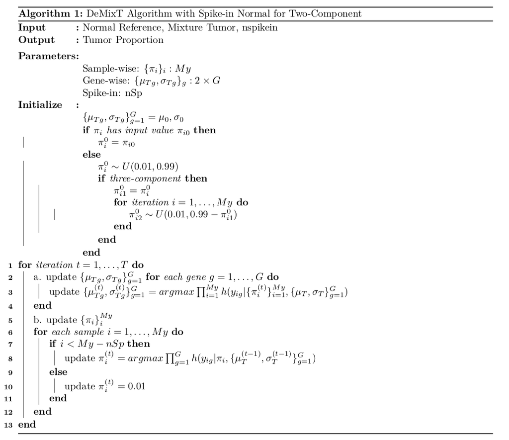

# 5. Examples

## 5.1 Simulated two-component data

```r
data("test.data.2comp")
# res.GS = DeMixT_GS(data.Y = test.data.2comp$data.Y,
#                     data.N1 = test.data.2comp$data.N1,
#                     niter = 30, nbin = 50, nspikein = 50,
#                     if.filter = TRUE, ngene.Profile.selected = 150,
#                     mean.diff.in.CM = 0.25, ngene.selected.for.pi = 150,
#                     tol = 10^(-5))
load('Res_2comp/res.GS.RData')
```

```r
head(t(res.GS$pi))
```

```
##               PiN1       PiT
## Sample 1 0.5955120 0.4044880
## Sample 2 0.2759014 0.7240986
## Sample 3 0.5401655 0.4598345
## Sample 4 0.4497041 0.5502959
## Sample 5 0.6516980 0.3483020
## Sample 6 0.4365191 0.5634809
```

```r
head(res.GS$gene.name)
```

```
## [1] "Gene 418" "Gene 452" "Gene 421" "Gene 112" "Gene 154" "Gene 143"
```

```r
data("test.data.2comp")
# res.S2 <- DeMixT_S2(data.Y = test.data.2comp$data.Y,
#                     data.N1 = test.data.2comp$data.N1,
#                     data.N2 = NULL,
#                     givenpi = c(t(res.S1$pi[-nrow(res.GS$pi),])), nbin = 50)
load('Res_2comp/res.S2.RData')
```

```r
head(res.S2$decovExprT[,1:5],3)
```

```
##         Sample 1  Sample 2  Sample 3 Sample 4  Sample 5
## Gene 1  23.44572  63.05155 149.43142 89.72656  48.22207
## Gene 2  18.91726  37.71497  20.54948 28.20727  23.01847
## Gene 3 104.62971 299.57097 145.90209 84.40262 544.63125
```

```r
head(res.S2$decovExprN1[,1:5],3)
```

```
##         Sample 1  Sample 2  Sample 3  Sample 4  Sample 5
## Gene 1  60.10972  71.06029  74.10607  72.68732  71.87571
## Gene 2 107.17312 107.96183 110.86023 115.54974 124.78271
## Gene 3 520.26197 649.41668 606.04119 522.14819 722.69642
```

```r
head(res.S2$decovMu,3)
```

```
##            MuN1      MuT
## Gene 1 6.166484 6.011676
## Gene 2 6.677594 4.647206
## Gene 3 9.329628 7.997622
```

```r
head(res.S2$decovSigma,3)
```

```
##          SigmaN1    SigmaT
## Gene 1 0.2222914 0.9541641
## Gene 2 0.2319681 0.8855282
## Gene 3 0.1881647 0.9197396
```

## 5.2 Simulated two-component data with DeMixT Spike-in Normal

In the simulation,

```markdown
## Simulate MuN and MuT for each gene
  MuN <- rnorm(G, 7, 1.5)
  MuT <- rnorm(G, 7, 1.5)
  Mu <- cbind(MuN, MuT)
## Simulate SigmaN and SigmaT for each gene
  SigmaN <- runif(n = G, min = 0.1, max = 0.8)
  SigmaT <- runif(n = G, min = 0.1, max = 0.8)
## Simulate Tumor Proportion
  PiT = truncdist::rtrunc(n = My,
                          spec = 'norm',
                          mean = 0.55,
                          sd = 0.2,
                          a = 0.25,
                          b = 0.95)

## Simulate Data
  for(k in 1:G){

    data.N1[k,] <- 2^rnorm(M1, MuN[k], SigmaN[k]); # normal reference

    True.data.T[k,] <- 2^rnorm(My, MuT[k], SigmaT[k]);  # True Tumor

    True.data.N1[k,] <- 2^rnorm(My, MuN[k], SigmaN[k]);  # True Normal

    data.Y[k,] <- pi[1,]*True.data.N1[k,] + pi[2,]*True.data.T[k,] # Mixture Tumor

  }
```

where $\pi_i \in (0.25, 0.95)$ is from truncated normal distribution. In general, the true distribution of tumor proportion does not follow a uniform distribution between $[0,1]$, but instead skewed to the upper part of the interval.

```r
# ## DeMixT_S1 without Spike-in Normal
# res.S1 = DeMixT_S1(data.Y = test.data.2comp$data.Y,
#                    data.N1 = test.data.2comp$data.N1,
#                    niter = 30, nbin = 50, nspikein = 0,
#                    if.filter = TRUE,
#                    mean.diff.in.CM = 0.25, ngene.selected.for.pi = 150,
#                    tol = 10^(-5))
# ## DeMixT_S1 with Spike-in Normal
# res.S1.SP = DeMixT_S1(data.Y = test.data.2comp$data.Y,
#                      data.N1 = test.data.2comp$data.N1,
#                      niter = 30, nbin = 50, nspikein = 50,
#                      if.filter = TRUE,
#                      mean.diff.in.CM = 0.25, ngene.selected.for.pi = 150,
#                      tol = 10^(-5))
# ## DeMixT_GS with Spike-in Normal
# res.GS.SP = DeMixT_GS(data.Y = test.data.2comp$data.Y,
#                      data.N1 = test.data.2comp$data.N1,
#                      niter = 30, nbin = 50, nspikein = 50,
#                      if.filter = TRUE, ngene.Profile.selected = 150,
#                      mean.diff.in.CM = 0.25, ngene.selected.for.pi = 150,
#                      tol = 10^(-5))
load('Res_2comp/res.S1.RData'); load('Res_2comp/res.S1.SP.RData');
load('Res_2comp/res.GS.RData'); load('Res_2comp/res.GS.SP.RData');
```

This simulation was designed to compare previous DeMixT resutls with DeMixT spike-in results under both gene selection method.

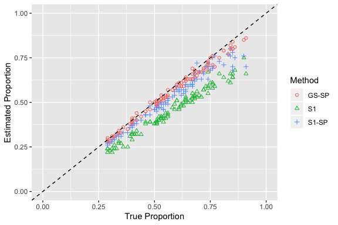

```r
res.2comp = as.data.frame(cbind(round(rep(t(test.data.2comp$pi[2,]),3),2),
                                round(c(t(res.S1$pi[2,]),t(res.S1.SP$pi[2,]), t(res.GS.SP$pi[2,])),2),
                                rep(c('S1','S1-SP','GS-SP'), each = 100)), num = 1:2)
res.2comp$V1 <- as.numeric(as.character(res.2comp$V1))
res.2comp$V2 <- as.numeric(as.character(res.2comp$V2))
res.2comp$V3 = as.factor(res.2comp$V3)
names(res.2comp) = c('True.Proportion', 'Estimated.Proportion', 'Method')
## Plot
ggplot(res.2comp, aes(x=True.Proportion, y=Estimated.Proportion, group = Method, color=Method, shape=Method)) +
  geom_point() +
  geom_abline(intercept = 0, slope = 1, linetype = "dashed", color = "black", lwd = 0.5) +
  xlim(0,1) + ylim(0,1)  +
  scale_shape_manual(values=c(seq(1:3))) +
  labs(x = 'True Proportion', y = 'Estimated Proportion')
```

## 5.3 Simulated three-component data

In this simulation,

```markdown
G <- G1 + G2
## Simulate MuN1, MuN2 and MuT for each gene
  MuN1 <- rnorm(G, 7, 1.5)
  MuN2_1st <- MuN1[1:G1] + truncdist::rtrunc(n = 1,
                                             spec = 'norm',
                                             mean = 0,
                                             sd = 1.5,
                                             a = -0.1,
                                             b = 0.1)
  MuN2_2nd <- c()
  for(l in (G1+1):G){
    tmp <- MuN1[l] + truncdist::rtrunc(n = 1,
                                       spec = 'norm',
                                       mean = 0,
                                       sd = 1.5,
                                       a = 0.1,
                                       b = 3)^rbinom(1, size=1, prob=0.5)
    while(tmp <= 0) tmp <- MuN1[l] + truncdist::rtrunc(n = 1,
                                                       spec = 'norm',
                                                       mean = 0,
                                                       sd = 1.5,
                                                       a = 0.1,
                                                       b = 3)^rbinom(1, size=1, prob=0.5)
    MuN2_2nd <- c(MuN2_2nd, tmp)
  }
## Simulate SigmaN1, SigmaN2 and SigmaT for each gene
  SigmaN1 <- runif(n = G, min = 0.1, max = 0.8)
  SigmaN2 <- runif(n = G, min = 0.1, max = 0.8)
  SigmaT <- runif(n = G, min = 0.1, max = 0.8)
## Simulate Tumor Proportion
  pi <- matrix(0, 3, My)
  pi[1,] <- runif(n = My, min = 0.01, max = 0.97)
  for(j in 1:My){
    pi[2, j] <- runif(n = 1, min = 0.01, max = 0.98 - pi[1,j])
    pi[3, j] <- 1 - sum(pi[,j])
  }
## Simulate Data
  for(k in 1:G){

    data.N1[k,] <- 2^rnorm(M1, MuN1[k], SigmaN1[k]); # normal reference 1

    data.N2[k,] <- 2^rnorm(M2, MuN2[k], SigmaN2[k]); # normal reference 1

    True.data.T[k,] <- 2^rnorm(My, MuT[k], SigmaT[k]);  # True Tumor

    True.data.N1[k,] <- 2^rnorm(My, MuN1[k], SigmaN1[k]);  # True Normal 1

    True.data.N2[k,] <- 2^rnorm(My, MuN2[k], SigmaN2[k]);  # True Normal 1

    data.Y[k,] <- pi[1,]*True.data.N1[k,] + pi[2,]*True.data.N2[k,] +
      pi[3,]*True.data.T[k,] # Mixture Tumor

  }
```

where $G1$ is the number of genes that $\mu_{N1}$ is close to $\mu_{N2}$.

```r
data("test.data.3comp")
# res.S1 <- DeMixT_S1(data.Y = test.data.3comp$data.Y, data.N1 = test.data.3comp$data.N1,
#                    data.N2 = test.data.3comp$data.N2, if.filter = TRUE)
load('Res_3comp/res.S1.RData');
```

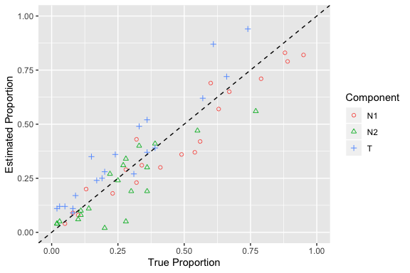

```r
res.3comp= as.data.frame(cbind(round(t(matrix(t(test.data.3comp$pi), nrow = 1)),2),
                                round(t(matrix(t(res.S1$pi), nrow = 1)),2),
                                rep(c('N1','N2','T'), each = 20)))
res.3comp$V1 <- as.numeric(as.character(res.3comp$V1))
res.3comp$V2 <- as.numeric(as.character(res.3comp$V2))
res.3comp$V3 = as.factor(res.3comp$V3)
names(res.3comp) = c('True.Proportion', 'Estimated.Proportion', 'Component')
## Plot
ggplot(res.3comp, aes(x=True.Proportion, y=Estimated.Proportion, group = Component, color=Component, shape=Component)) +
  geom_point() +
  geom_abline(intercept = 0, slope = 1, linetype = "dashed", color = "black", lwd = 0.5) +
  xlim(0,1) + ylim(0,1)  +
  scale_shape_manual(values=c(seq(1:3))) +
  labs(x = 'True Proportion', y = 'Estimated Proportion')
```

## 5.4 PRAD in TCGA Dataset

```r
load('res.PRAD.RData');
```

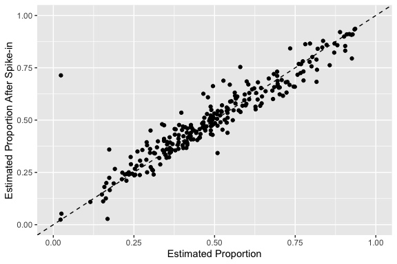

```r
res.PRAD.df = as.data.frame(cbind(res.PRAD$res.GS.PRAD, res.PRAD$res.GS.SP.PRAD))
res.PRAD.df$V1 <- as.numeric(as.character(res.PRAD.df$V1))
res.PRAD.df$V2 <- as.numeric(as.character(res.PRAD.df$V2))
names(res.PRAD.df) = c('Estimated.Proportion', 'Estimated.Proportion.SP')
## Plot
ggplot(res.PRAD.df, aes(x=Estimated.Proportion, y=Estimated.Proportion.SP)) +
  geom_point() +
  geom_abline(intercept = 0, slope = 1, linetype = "dashed", color = "black", lwd = 0.5) +
  xlim(0,1) + ylim(0,1)  +
  scale_shape_manual(values=c(seq(1:3))) +
  labs(x = 'Estimated Proportion', y = 'Estimated Proportion After Spike-in')
```

Tumor proportion estimation remains consistence with and without spike-in normal, when its distribution is roughly symmetric around 0.5.